# Logistic Regression

Angel Rios

```python
%matplotlib inline
import matplotlib.pyplot as plt
import pandas as pd
import seaborn as sns
import warnings

from sklearn.decomposition import PCA
from IPython.display import display, HTML

pd.set_option('max_colwidth',100)
warnings.filterwarnings('ignore')
plt.style.use('ggplot')
```

```python
run MvaUtils.py
```

Loading the datasets

```python
features = ['fixedAcidity','volatileAcidity','citricAcid',\
            'residualSugar','chlorides','freeSulfurDioxide',\
            'totalSulfurdioxide','density', 'pH','sulphates',\
            'alcohol','quality']

whiteWinnePath = 'DataSets/winequalityWhite.csv'
redWinnePath = 'DataSets/winequalityRed.csv'

whiteWinePD = pd.read_csv(whiteWinnePath)
redWinePD = pd.read_csv(redWinnePath)
```

```python
from sklearn.model_selection import train_test_split
from sklearn.preprocessing import StandardScaler

redWineTrain,redWineTest = train_test_split(redWinePD,test_size=0.3)
whiteWineTrain,whiteWineTest = train_test_split(whiteWinePD,test_size=0.3)

pd.concat([redWineTrain,whiteWineTrain]).loc[:,features]
```

|  | fixedAcidity | volatileAcidity | citricAcid | residualSugar | chlorides | freeSulfurDioxide | totalSulfurdioxide | density | pH | sulphates | alcohol | quality |
| --- | --- | --- | --- | --- | --- | --- | --- | --- | --- | --- | --- | --- |
| 1198 | 7.7 | 0.260 | 0.26 | 2.0 | 0.052 | 19.0 | 77.0 | 0.99510 | 3.15 | 0.79 | 10.9 | 6 |
| 1457 | 7.6 | 0.490 | 0.33 | 1.9 | 0.074 | 27.0 | 85.0 | 0.99706 | 3.41 | 0.58 | 9.0 | 5 |
| 364 | 12.8 | 0.615 | 0.66 | 5.8 | 0.083 | 7.0 | 42.0 | 1.00220 | 3.07 | 0.73 | 10.0 | 7 |
| 972 | 10.1 | 0.380 | 0.50 | 2.4 | 0.104 | 6.0 | 13.0 | 0.99643 | 3.22 | 0.65 | 11.6 | 7 |
| 94 | 5.0 | 1.020 | 0.04 | 1.4 | 0.045 | 41.0 | 85.0 | 0.99380 | 3.75 | 0.48 | 10.5 | 4 |
| ... | ... | ... | ... | ... | ... | ... | ... | ... | ... | ... | ... | ... |
| 4404 | 5.9 | 0.290 | 0.16 | 7.9 | 0.044 | 48.0 | 197.0 | 0.99512 | 3.21 | 0.36 | 9.4 | 5 |
| 1170 | 7.7 | 0.250 | 0.43 | 4.5 | 0.062 | 20.0 | 115.0 | 0.99660 | 3.38 | 0.50 | 9.9 | 6 |
| 1794 | 6.6 | 0.370 | 0.24 | 2.0 | 0.064 | 23.0 | 120.0 | 0.99460 | 3.32 | 0.54 | 9.4 | 5 |
| 381 | 7.2 | 0.280 | 0.26 | 12.5 | 0.046 | 48.0 | 179.0 | 0.99750 | 3.10 | 0.52 | 9.0 | 6 |
| 273 | 6.6 | 0.580 | 0.30 | 5.1 | 0.057 | 30.0 | 123.0 | 0.99490 | 3.24 | 0.38 | 9.0 | 5 |

4547 rows × 12 columns

Standarizing the features of the dataset to avoid that all the variability is absorbed by some columns due to the different units of measurement

```python
wineTrainPD = pd.concat([redWineTrain,whiteWineTrain]).loc[:,features]

scalerWine = StandardScaler(with_mean=True,with_std=True).fit(wineTrainPD.values)
```

**PCA**

```
PCA Transformation Matrix:
```

|  | pc1 | pc2 | pc3 | pc4 | pc5 | pc6 | pc7 | pc8 | pc9 | pc10 | pc11 | pc12 |
| --- | --- | --- | --- | --- | --- | --- | --- | --- | --- | --- | --- | --- |
| 0 | 0.271202 | 0.247476 | 0.465853 | -0.118445 | 0.153716 | -0.028445 | -0.425887 | -0.049795 | -0.396255 | 0.288597 | -0.262015 | -0.341909 |
| 1 | 0.396005 | 0.087688 | -0.282335 | -0.083658 | 0.162078 | 0.395437 | -0.406166 | -0.327006 | 0.160886 | -0.496909 | 0.120641 | -0.082940 |
| 2 | -0.137491 | 0.150815 | 0.588576 | 0.050803 | -0.253275 | -0.331330 | -0.004377 | -0.448889 | 0.284802 | -0.330221 | 0.209148 | -0.000114 |
| 3 | -0.304220 | 0.357543 | -0.070514 | 0.128836 | 0.513313 | 0.061647 | 0.140650 | -0.043625 | 0.472712 | 0.200492 | 0.010524 | -0.453102 |
| 4 | 0.324169 | 0.254997 | 0.041442 | 0.147545 | -0.400685 | 0.452413 | 0.501674 | -0.299683 | 0.038706 | 0.245234 | -0.189989 | -0.044244 |
| 5 | -0.419207 | 0.116561 | -0.101569 | 0.294351 | -0.261974 | 0.304849 | -0.370071 | -0.143386 | -0.247106 | 0.290098 | 0.499424 | -0.001273 |
| 6 | -0.470335 | 0.157276 | -0.100608 | 0.129208 | -0.218939 | 0.117904 | -0.234323 | -0.014856 | 0.010193 | -0.272150 | -0.729536 | 0.062263 |
| 7 | 0.113389 | 0.553871 | -0.050569 | 0.164273 | 0.313914 | -0.156534 | -0.022442 | -0.067911 | -0.070943 | 0.087566 | -0.001255 | 0.714118 |
| 8 | 0.199813 | -0.154059 | -0.420616 | 0.462292 | -0.052384 | -0.543688 | -0.066875 | -0.395224 | -0.086384 | 0.132796 | -0.133378 | -0.209302 |
| 9 | 0.304853 | 0.111397 | 0.151825 | 0.579856 | -0.195897 | 0.002012 | -0.183372 | 0.604891 | 0.273347 | -0.116786 | 0.055699 | -0.077552 |
| 10 | 0.049471 | -0.496633 | 0.213939 | 0.092556 | 0.123702 | 0.185148 | -0.288699 | -0.193788 | 0.462016 | 0.416642 | -0.183884 | 0.324385 |
| 11 | -0.089308 | -0.295934 | 0.285347 | 0.499187 | 0.436333 | 0.251686 | 0.261462 | -0.111052 | -0.386255 | -0.299427 | -0.022130 | 0.008409 |

|  | explained variance |
| --- | --- |
| 0 | 0.255625 |
| 1 | 0.218506 |
| 2 | 0.137924 |
| 3 | 0.091045 |
| 4 | 0.069507 |
| 5 | 0.053623 |
| 6 | 0.047099 |
| 7 | 0.042605 |
| 8 | 0.037742 |
| 9 | 0.024824 |
| 10 | 0.018673 |
| 11 | 0.002827 |

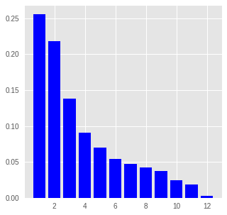

```python
kw=12
pcaWineCols = ['pc'+str(i+1) for i in range(0,kw)]

wineTrainX = scalerWine.transform(wineTrainPD.loc[:,features].values)

pcaStdWineModel = PCA(n_components=kw).fit(wineTrainX)
pcaStdWineMatrix = pd.DataFrame(pcaStdWineModel.components_.transpose(),columns=pcaWineCols)

print('PCA Transformation Matrix:\n')
display(pcaStdWineMatrix)
plt.figure(figsize=(5,5))
screePlot(plt,pcaStdWineModel.explained_variance_ratio_)
```

**Biplot**

Ploting the transformed dataset and the projection of the canonical base taking only 2 components in to two dimension space.

```python
stdRedWineTrainX = scalerWine.transform(redWineTrain.values)
stdWhiteWineTrainX = scalerWine.transform(whiteWineTrain.values)

pcaStdRedWineTrainPD = pd.DataFrame(pcaStdWineModel.transform(stdRedWineTrainX),\
                                    columns=pcaWineCols)
pcaStdWhiteWineTrainPD = pd.DataFrame(pcaStdWineModel.transform(stdWhiteWineTrainX),\
                                      columns=pcaWineCols)
```

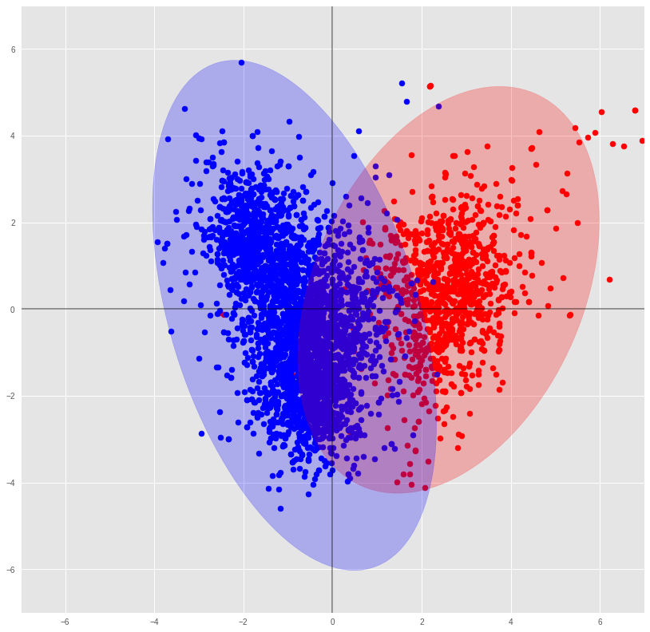

```python
cols = ['pc1','pc2']
alpha=0.03
df=2
plt.figure(figsize=(14,14))
plt.axis([-7,7,-7,7])

getProbabilityDensityContour(plt,pcaStdRedWineTrainPD,cols,alpha,df,color='Red')
scatterPlot(plt,pcaStdRedWineTrainPD,'pc1','pc2','Red',color='Black',alpha=0.25)

getProbabilityDensityContour(plt,pcaStdWhiteWineTrainPD,cols,alpha,df,color='Blue')
scatterPlot(plt,pcaStdWhiteWineTrainPD,'pc1','pc2','Blue',color='Black',alpha=0.25)

plt.show()
```

Applying the pca to the validation dataset

```python
stdRedWineTestX = scalerWine.transform(redWineTest.values)
stdWhiteWineTestX = scalerWine.transform(whiteWineTest.values)

pcaStdRedWineTestPD = pd.DataFrame(pcaStdWineModel.transform(stdRedWineTestX),\
                                   columns=pcaWineCols)
pcaStdWhiteWineTestPD = pd.DataFrame(pcaStdWineModel.transform(stdWhiteWineTestX),\
                                     columns=pcaWineCols)
```

Visualizing the set of validation data without labels, it is clear that there are two groups, however there are samples that are scattered and it is not clear to what type of population it belongs

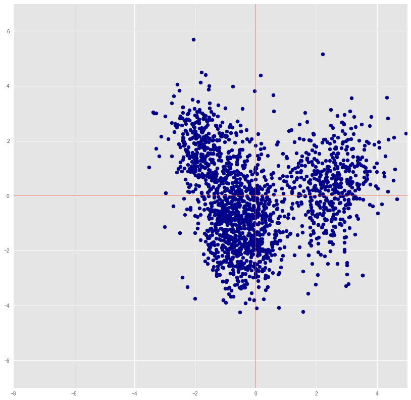

```python
cols = ['pc1','pc2']
alpha=0.03
df=2
plt.figure(figsize=(14,14))
plt.axis([-8,5,-7,7])
scatterPlot(plt,pcaStdRedWineTestPD,'pc1','pc2',alpha=0.25)
scatterPlot(plt,pcaStdWhiteWineTestPD,'pc1','pc2',alpha=0.25)
plt.show()
```

**Fiting the logistic regression**

```python
from sklearn.linear_model import LogisticRegression

pcaStdRedWineTrainPD['target'] = [1]*len(pcaStdRedWineTrainPD)
pcaStdWhiteWineTrainPD['target'] = [0]*len(pcaStdWhiteWineTrainPD)

pcaStdRedWineTestPD['target'] = [1]*len(pcaStdRedWineTestPD)
pcaStdWhiteWineTestPD['target'] = [0]*len(pcaStdWhiteWineTestPD)

trainPD = pd.concat([pcaStdRedWineTrainPD,pcaStdWhiteWineTrainPD])
testPD = pd.concat([pcaStdRedWineTestPD,pcaStdWhiteWineTestPD])
```

```python
trainX = trainPD.loc[:,pcaWineCols].values
trainY = trainPD[['target']].values

lrModel = LogisticRegression(random_state=1,penalty='l2').fit(trainX,trainY)

trainPD['prob0'] = pd.DataFrame(lrModel.predict_proba(trainX))[0]
trainPD['prob1'] = pd.DataFrame(lrModel.predict_proba(trainX))[1]
trainPD['target_est'] = lrModel.predict(trainX)
trainPD[['target','prob0','prob1','target_est']]
```

|  | target | prob0 | prob1 | target_est |
| --- | --- | --- | --- | --- |
| 0 | 1 | 0.242702 | 0.757298 | 1 |
| 1 | 1 | 0.048857 | 0.951143 | 1 |
| 2 | 1 | 0.000025 | 0.999975 | 1 |
| 3 | 1 | 0.000479 | 0.999521 | 1 |
| 4 | 1 | 0.006874 | 0.993126 | 1 |
| ... | ... | ... | ... | ... |
| 3423 | 0 | 0.990124 | 0.009876 | 0 |
| 3424 | 0 | 0.996225 | 0.003775 | 0 |
| 3425 | 0 | 0.816116 | 0.183884 | 0 |
| 3426 | 0 | 0.999223 | 0.000777 | 0 |
| 3427 | 0 | 0.998642 | 0.001358 | 0 |

4547 rows × 4 columns

```python
testX = testPD.loc[:,pcaWineCols].values
testPD['prob0'] = pd.DataFrame(lrModel.predict_proba(testX))[0]
testPD['prob1'] = pd.DataFrame(lrModel.predict_proba(testX))[1]
testPD['target_est'] = lrModel.predict(testX)
testPD[['target','prob0','prob1','target_est']]
```

|  | target | prob0 | prob1 | target_est |
| --- | --- | --- | --- | --- |
| 0 | 1 | 0.000353 | 0.999647 | 1 |
| 1 | 1 | 0.030100 | 0.969900 | 1 |
| 2 | 1 | 0.000259 | 0.999741 | 1 |
| 3 | 1 | 0.022599 | 0.977401 | 1 |
| 4 | 1 | 0.996675 | 0.003325 | 0 |
| ... | ... | ... | ... | ... |
| 1465 | 0 | 0.998628 | 0.001372 | 0 |
| 1466 | 0 | 0.997476 | 0.002524 | 0 |
| 1467 | 0 | 0.856222 | 0.143778 | 0 |
| 1468 | 0 | 0.999986 | 0.000014 | 0 |
| 1469 | 0 | 0.999461 | 0.000539 | 0 |

1950 rows × 4 columns

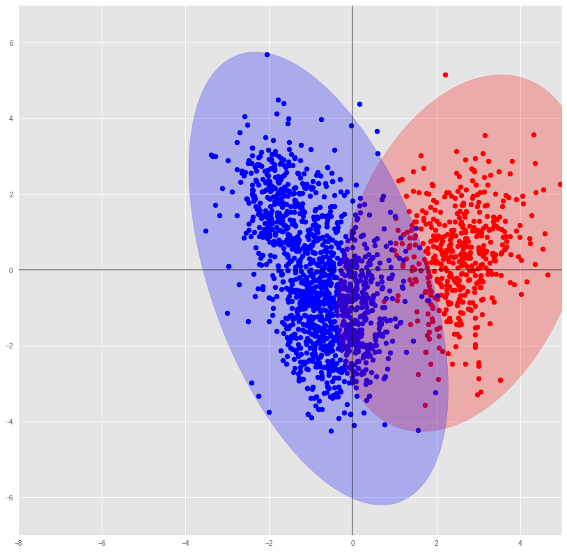

```python
cols = ['pc1','pc2']
alpha=0.03
df=2
plt.figure(figsize=(14,14))
plt.axis([-8,5,-7,7])

inferredTruesTestPD = testPD[testPD['target_est']==1]
inferredFalsesTestPD = testPD[testPD['target_est']==0]

getProbabilityDensityContour(plt,inferredTruesTestPD,cols,alpha,df,color='Red')
scatterPlot(plt,inferredTruesTestPD,'pc1','pc2','Red',color='Black',alpha=0.25)

getProbabilityDensityContour(plt,inferredFalsesTestPD,cols,alpha,df,color='Blue')
scatterPlot(plt,inferredFalsesTestPD,'pc1','pc2','Blue',color='Black',alpha=0.25)

plt.show()
```

```python
coeficients = list(lrModel.coef_[0][:2])
intercept = list(lrModel.intercept_)

print('coeficients: ',coeficients)
print('intercept: ',intercept)
```

```
coeficients:  [3.4552183878496794, 0.15570363777526466]
intercept:  [-3.8224882925626815]
```

```python
def logisticSurface(coeficients,intercept,vector):
    logitTransformation = np.dot(coeficients,vector)+intercept
    return 1/(1+math.exp(-1*logitTransformation))
```

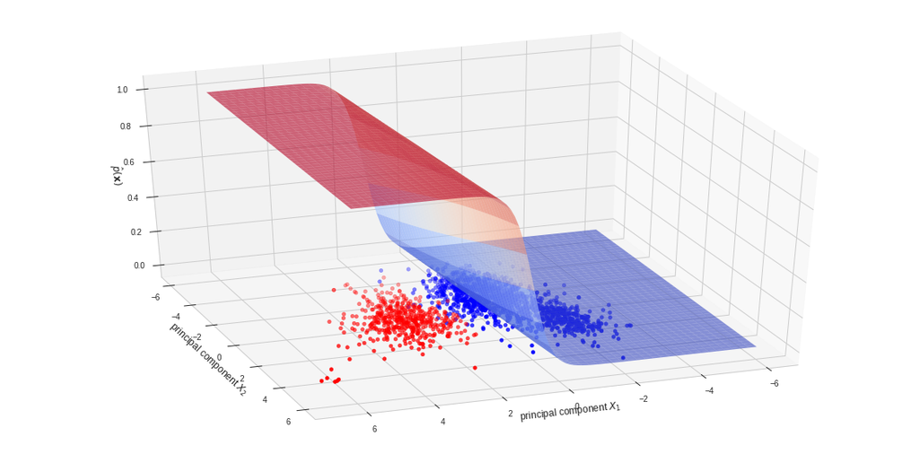

```python
from mpl_toolkits.mplot3d import Axes3D
import math

positivesX1 = list(inferredTruesTestPD['pc1'].values)
positivesX2 = list(inferredTruesTestPD['pc2'].values)
negativesX1 = list(inferredFalsesTestPD['pc1'].values)
negativesX2 = list(inferredFalsesTestPD['pc2'].values)

plt.style.use('seaborn-whitegrid')
fig = plt.figure(figsize=(20,10))
ax = fig.add_subplot(111, projection='3d')
ax.scatter(positivesX1, positivesX2, 0, color="Red", marker='o')
ax.scatter(negativesX1, negativesX2, 0, color="Blue", marker='o')
ax.set_xlabel('principal component $X_1$')
ax.set_ylabel('principal component $X_2$')
ax.set_zlabel('$\hat{p}(\mathbf{x})$')
x1 = np.linspace(-6,6,100)
x2 = np.linspace(-6,6,100)
X1, X2 = np.meshgrid(x1,x2)
Z = np.array([[logisticSurface(coeficients,intercept,[x1,x2])
               for x1 in x1] for x2 in x2])
ax.plot_surface(X1,X2,Z,cmap='coolwarm',alpha=0.6,linewidth=0)
ax.view_init(35,70)
plt.show()
```

```python
import numpy as np
from scipy.stats import norm
import statsmodels.api as sm

sm_model = sm.Logit(trainY, sm.add_constant(trainX)).fit(disp=0)
sm_model.summary()
```

Logit Regression Results

| Dep. Variable: | y | No. Observations: | 4547 |
| --- | --- | --- | --- |
| Model: | Logit | Df Residuals: | 4534 |
| Method: | MLE | Df Model: | 12 |
| Date: | Wed, 27 May 2020 | Pseudo R-squ.: | 0.9332 |
| Time: | 18:45:05 | Log-Likelihood: | -169.45 |
| converged: | True | LL-Null: | -2537.3 |
| Covariance Type: | nonrobust | LLR p-value: | 0.000 |

|  | coef | std err | z | P>\|z\| | [0.025 | 0.975] |
| --- | --- | --- | --- | --- | --- | --- |
| const | -4.0571 | 0.327 | -12.415 | 0.000 | -4.698 | -3.417 |
| x1 | 3.6597 | 0.237 | 15.446 | 0.000 | 3.195 | 4.124 |
| x2 | 0.0771 | 0.150 | 0.513 | 0.608 | -0.218 | 0.372 |
| x3 | 0.2436 | 0.143 | 1.703 | 0.089 | -0.037 | 0.524 |
| x4 | 0.8380 | 0.152 | 5.523 | 0.000 | 0.541 | 1.135 |
| x5 | -0.1976 | 0.246 | -0.805 | 0.421 | -0.679 | 0.284 |
| x6 | 0.4091 | 0.179 | 2.280 | 0.023 | 0.057 | 0.761 |
| x7 | -0.9629 | 0.218 | -4.410 | 0.000 | -1.391 | -0.535 |
| x8 | -0.7449 | 0.225 | -3.307 | 0.001 | -1.186 | -0.303 |
| x9 | -1.5396 | 0.265 | -5.809 | 0.000 | -2.059 | -1.020 |
| x10 | 0.8856 | 0.297 | 2.981 | 0.003 | 0.303 | 1.468 |
| x11 | 2.0612 | 0.386 | 5.344 | 0.000 | 1.305 | 2.817 |
| x12 | 5.1893 | 0.858 | 6.048 | 0.000 | 3.508 | 6.871 |

Possibly complete quasi-separation: A fraction 0.25 of observations can be  
perfectly predicted. This might indicate that there is complete  
quasi-separation. In this case some parameters will not be identified.

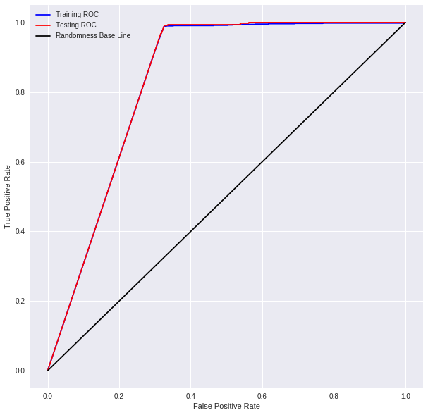

```
AUC TRAIN: 0.8335916799359322
AUC TEST: 0.8352791950113378
GINI TRAIN: 0.6671833598718644
GINI TEST: 0.6705583900226757
```

```python
from sklearn.metrics import roc_curve, roc_auc_score
pd.set_option('max_colwidth',100)
plt.style.use('seaborn-paper')
plt.style.use('seaborn')

train_fpr, train_tpr, train_thresholds  = roc_curve(trainPD['target'],trainPD['prob1'])
test_fpr, test_tpr, test_thresholds  = roc_curve(testPD['target'],testPD['prob1'])

plt.figure(figsize=(10,10))
plt.plot(train_fpr,train_tpr, linestyle='-', color='blue', label='Training ROC')
plt.plot(test_fpr,test_tpr, linestyle='-', color='red', label='Testing ROC')
plt.plot([0,1],[0,1], color='black', label='Randomness Base Line')
plt.xlabel('False Positive Rate')
plt.ylabel('True Positive Rate')
plt.legend()
plt.show()
from sklearn.metrics import roc_auc_score
print('AUC TRAIN:',roc_auc_score(trainPD['target'],trainPD['prob1']))
print('AUC TEST:',roc_auc_score(testPD['target'],testPD['prob1']))
print('GINI TRAIN:',2*roc_auc_score(trainPD['target'],trainPD['prob1'])-1)
print('GINI TEST:',2*roc_auc_score(testPD['target'],testPD['prob1'])-1)
```